# Business customers' satisfaction: What happens when suppliers downsize?

Converted from PDF `Lewin-SupplierDownsizingCustomerSatisfaction-2009-IMM.pdf` · 17 pages · anchors: page `#pN`, block `#pN-bK`

Page 1

### Business customers' satisfaction: What happens when suppliers downsize?

### Jeffrey E. Lewin <sup>⁎</sup>

University of North Texas, College of Business Administration, Department of Marketing and Logistics, P. O. Box 311396, Denton, TX 76203-1396, United States

Received 28 November 2006; received in revised form 24 November 2007; accepted 25 November 2007

Available online 11 March 2008

Abstract

Organizational downsizing has become commonplace in today's competitive environments. Over the past 10 years in the U.S. alone over 10 million positions have been eliminated. Recently, questions related to the holistic benefits of downsizing have emerged. One of these questions suggests that downsized companies may find it more difficult to fully satisfy their customers; especially if there have been significant cuts in key contact personnel. In view of this question, the work presented here examines whether downsized suppliers, as compared to non-downsized suppliers, enjoy higher (or lower) levels of customer satisfaction and loyalty among their business customers. Based on a sample of 560 purchasing professionals, this study indicates that contrary to popular managerial schema ([Lewin, J. E. (2003). An empirical investigation of the effects of downsizing on buyer–seller relationships. Journal of Business Research, 56(4), 283–293]; [McKinley, W., Zhao, J., & Rust, K. (2000). A socio-cognitive interpretation of organizational downsizing. Academy of Management Review, 25(1), 227–243]), downsized suppliers do a significantly worse job in delivering quality and value to their business customers. As a result, their customers are less satisfied and less loyal. © 2008 Elsevier Inc. All rights reserved.

Keywords: Downsizing; Business customers' satisfaction

1. Introduction

Customer satisfaction significantly influences an organization's current and future performance (Anderson, Fornell, & Lehmann, 1994). Prior research suggests that customer satisfaction is an important source of competitive advantage (e.g., Rust, Zeithaml, & Lemon, 2000), often leading to customer loyalty and repeat purchase (Bolton, 1998; Lam et al., 2004). The benefits of customer satisfaction include increases in revenues, decreases in customer-related transaction costs, and reductions in price elasticity among repeat buyers (Fornell, 1992).

One important source of customer satisfaction is consistent, positive interactions with a firm's sales and customer servicesupport personnel. Key contact employees have been shown to influence customer satisfaction in a variety of settings including

consumer services (Heskett, Jones, Loveman, Sasser, & Schlesinger, 1994) and industrial manufacturing and distribution (Bendapudi & Leone, 2002). Often, business customers' relationships with their suppliers' sales and customer-support personnel are as strong (or even stronger) than their relationships with the vendor firms themselves (e.g., Gwinner, Gremler, & Bitner, 1998). Further, the relationships between organizations (i.e., buyer and supplier firms) are frequently anchored in the personal relationships among the staff within the respective organizations—i.e., purchasers and sales/support personnel (Lian & Laing, 2007). As such, the professional and interpersonal relationships among these boundary spanner personnel often significantly influence the continued success of the inter-organizational relationship (Granovetter, 1985); leading Ennew and Ahmed (1999) to argue that these types of interpersonal, inter-firm relationships can foster satisfaction even when technical performance fluctuates. Thus, when a supplier's key contact employees are no longer available, as is often the case in downsized firms (e.g., Eisenberg, 1997; Markels & Murray, 1996; Wilkinson, 2005), the relationships between the supplier and its customers become vulnerable to

Available online at www.sciencedirect.com

Industrial Marketing Management 38 (2009) 283–299

⁎ Tel.: +1 940 565 4419; fax: +1 940 565 3837.

E-mail address: lewinj@unt.edu.

0019-8501/$ - see front matter © 2008 Elsevier Inc. All rights reserved. doi:10.1016/j.indmarman.2007.11.005

Page 2

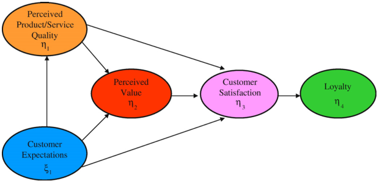

NOTE: figure/graphic rendered as an image from the PDF; its content is not machine-readable text. Caption (if any) follows as the next block.

competitive actions and customer defections (Bendapudi & Leone, 2002).

Interestingly, it appears as if the important relationship between customer satisfaction and stability in key contact personnel is overlooked by organizations engaging in downsizing activities. Instead, these organizations focus on the savings found in reduced operating expenses – i.e., reductions in employee wages, health and retirement benefits, etc. – and, the often anticipated improvements in flexibility and market responsiveness as a result of their downsizing initiatives. Recently, however, the hidden costs and holistic benefits of downsizing have come into question. Among these costs is the inability to fully satisfy customer needs and the concomitant reduction in customer satisfaction (Fornell, Johnson, Anderson, Cha, & Bryant, 1996).

While limited research, coupled with anecdotal accounts, provide some insight into the relationship between organizational downsizing and customer satisfaction in business-toconsumer markets (e.g., Bryant, 1997; Fornell et al., 1996), to date no study has empirically examined these relationships in business-to-business markets. However, many believe that behavior among buyers in these two environments is significantly different; thus empirical findings from B2C research may not be readily applicable in B2B environments (e.g., Doney & Cannon, 1997; Ganesan, 1994; Edward, Gut, & Mavondo, 2007). This may be especially true when one considers the relationships among quality, value, satisfaction, and loyalty in B2B as compared to B2C environments (Lam et al., 2004); especially as it relates to the intangible aspects of the selling firm's offerings (Beverland, Napoli, & Lindgreen, 2007)—for example, the relationships buyers have with the suppliers' key contact personnel.

Therefore, a major contribution of this work is its empirical examination of these relationships in B2B contexts. More specifically, survey data collected from 560 purchasing professionals are used to compare downsized suppliers', versus non-

downsized suppliers', ability to satisfy their business customers. Adopting a model similar to the ones used to assess customer satisfaction in consumer markets (e.g., Fornell et al., 1996), customer satisfaction is positioned as the central construct in a system of relationships. As shown in Fig. 1, the proposed model suggests the antecedents of overall business customer satisfaction are customer expectations, perceived product/service quality, and perceived value. The outcome of overall business customer satisfaction is customer loyalty (including repeat purchase intentions).

The balance of this work is organized in the following manner. First, the potential link between organizational downsizing and customer satisfaction is outlined. Next, the relevant extant literature is reviewed, forming the basis for the study hypotheses. Then, the research methodology is discussed. Finally, a summary discussion is developed, followed by the study limitations and directions for future research.

2. Organizational downsizing and customer satisfaction

2.1. Organizational downsizing

Downsizing has become commonplace in industrialized markets (Nixon, Hitt, Lee, & Jeong, 2004). For example, between 1995 and 2005, approximately 10 million people lost their jobs to downsizing in the U.S. alone.<sup>1</sup> Both supplier and buyer firms have been affected by downsizing initiatives. However, according to the Bureau of Labor Statistics Data (2005), sales and marketing personnel have been hit harder than many other groups.

Fig. 1. Business customer satisfaction. The model exhibit above will be tested using a sample of 294 non-downsized suppliers and 266 downsized suppliers. The two groups will be compared, using SEM group comparison techniques, to assess (1) if there are significant differences in the two groups across modeled constructs, and (2) if significant differences exist—where and how those differences manifest.

1 This data was accumulated over time from various announcements posted on cnn.com, cnnfn.com, and from press releases obtained from Challenger, Gray, and Christmas Inc., a leading authority on organizational downsizing.

284 J.E. Lewin / Industrial Marketing Management 38 (2009) 283–299

Page 3

Not only have reductions in work force size increased in frequency in recent years (Burton, Mitchell, & Lee, 2005), they have changed in character as well (Hodson & Roscigno, 2004). In the past, layoffs were a last option used by managers confronted with recessions and/or plummeting firm performance (environmental decline). More recently, however, ‘healthy’ firms are using downsizing as a proactive management strategy in a continuous quest to reduce costs (Ferraro, Pfeffer, & Sutton, 2005). For example, Hewlett Packard announced plans to reduce staff by 10% (14,500 jobs) even after realizing significant increases in revenue and profit over the prior 3 years (CnnMoney.com, 2005). Similarly, Citigroup announced plans to cut 5.2% of its work force (17,000 jobs) after enjoying revenue growth of 35% over the prior 5 years (CNNMoney.com, 2007).

In an effort to explain these seemingly contradictory patterns, some argue that three forces (coercive-, mimetic-, and normative-isomorphism)<sup>2</sup> strongly influence managerial decisions related to corporate downsizing. These forces pressure firms to adopt currently accepted norms, practices, and philosophies (e.g., McKinley, Sanchez, & Schick, 1995). As such, present-day downsizing decisions often are not so much related to economic considerations as they are related to sociocognitive organizational schemas that view downsizing as effective, necessary, and inevitable—even if the consequences for the organization are uncertain (McKinley, Zhao, & Rust, 2000). The benefits extolled by downsizing supporters include decrease labor costs indirectly leading to increase productivity, streamlined operations, enhanced overall effectiveness, and increased competitive advantage (e.g., Lewin, 2003). However, it is not clear that firms engaging in major downsizing initiatives realize these benefits. This view is supported by recent empirical findings indicating no significant differences in financial performance, over time, between firms that have downsized and firms that have not downsized (e.g., Cascio, Young, & Morris, 1997; De Meuse, Bergmann, Vanderheiden, & Roraff, 2004; Nixon et al., 2004). Critics, on the other hand, argue that downsizing often has negative effects, such as escalating employee workloads, decreasing employee morale, accelerating employee stress and healthcare costs, increases in turnover, and decreases in the organization's ability to learn and adapt as a result of disruptions in informal communication networks (cf. De Meuse, et al., 2004; Mishra & Spreitzer, 1998).

2.2. Organizational downsizing and customer satisfaction

Increasingly, customer satisfaction is viewed as a key determinant of organizational success. Customer satisfaction has

been shown to positively influence repeat sales and/or repurchase intentions, and increase customer loyalty. As a result, customer satisfaction helps secure future revenue streams, create barriers to competitive efforts, inhibit customer defections, and reduce future transaction costs (e.g., Anderson et al., 1997; Homburg & Rudolph, 2001).

Equally strong arguments can be made for the benefits that accrue to organizations able to improve productivity; including increased earnings and/or the ability to better control product costs—leading to increased price flexibility and improved competitiveness. Common strategies to increase productivity include automation of processes, substituting capital for labor, and more recently, reductions in work force size (even within ‘healthy’ firms) with the expectation that the remaining employee base will make up the shortfall (Brockner, 1988; Oliva & Sterman, 2001).

Given the anticipated benefits of these dual objectives, many believe organizations can significantly improve overall performance by achieving gains in both productivity and customer satisfaction. On the surface the simultaneous pursuit of these two objectives seems reasonable. However, there may be situations where these two goals are incompatible. For example, when labor costs are reduced through downsizing, the result may be a relatively immediate gain in productivity. However, long-term firm performance likely will be at risk when customer satisfaction is dependent on the efforts of customer service-support personnel. When this is the case, there may be significant tradeoffs between productivity and customer satisfaction (e.g., Anderson et al., 1997; Heskett et al., 1994; Kamakura, Vikas, De Rosa, & Mazzon, 2002). Theoretical support for these propositions can be drawn from three distinct areas. First, work in the services marketing literature supports the view that (1) customer loyalty is a direct result of customer satisfaction, (2) customer satisfaction results from the levels of quality and value customers receive, and (3) quality and value are delivered by satisfied, loyal, and productive employees (e.g., Estelami & Hurley, 2003; Heskett et al., 1994). Second, work in the organizational behavior literature convincingly demonstrates that survivors of downsizing initiatives frequently suffer from ‘survivor syndrome’ (e.g., Brockner, Grover, Reed, DeWitt, & O'Malley, 1987; Mishra & Spreitzer, 1998). Manifestations of survivor syndrome include decreases in job satisfaction, morale, and commitment, along with increases in role conflict, fatigue, and turnover. By definition these manifestations, according to the services marketing literature previously cited, should inhibit employees' ability to deliver quality and value to the firm's customers. Third, work in the strategic management literature argues that when a firm significantly reduces the size of its workforce, that firm likely will suffer substantial losses in valuable human capital. The related losses in tacit knowledge and experience will further inhibit the downsized organization's ability to better satisfy its customers (Nixon et al., 2004; Oliva & Sterman, 2001), especially if the losses in human capital occur among key contact personnel (Bendapudi & Leone, 2002).

2 Coercive isomorphism compels firms to conform to institutional norms that define legitimate structures and activities. Mimetic isomorphism impels organizations to mimic the actions of recognized industry leaders. Normative isomorphism – emerging through professional conferences, seminars and networks – pressures executives to adopt currently accepted management practices and philosophies.

285 J.E. Lewin / Industrial Marketing Management 38 (2009) 283–299

Page 4

3. Study related hypotheses

The primary objective of this study is to investigate whether or not there are differences in the ability of downsized, versus non-downsized suppliers, to provide product/service quality and value to their business customers. Also, if differences exist to investigate whether or not these differences subsequently impact levels of customer satisfaction and loyalty. Tests of the hypotheses developed next should provide meaningful insight into these questions. In addition to testing the hypotheses proposed below, the (dis)similarities between the parameter estimates across the two structural models (non-downsized and downsized suppliers) will also be evaluated; with the purpose of providing additional contribution to the overall study results.

3.1. Pre-purchase expectations and post-purchase performance evaluations

The relationships among pre-purchase expectations, postpurchase evaluations of product/service quality, and overall customer satisfaction have received a significant amount of attention in consumer marketing research (e.g., Fornell, 1992; Fornell et al., 1996; Tse & Wilton, 1988). In contrast, their application in business marketing research has been limited (Lam et al., 2004). However, the links between expectations, performance quality, and satisfaction likely are stronger in business markets due to the direct impact many business purchase decisions have on subsequent firm performance (Cronin & Morris, 1989). Further, since professional buyers' expectations likely reflect more in-depth evaluations of alternative suppliers and clearer understandings of competitive capabilities, professional buyers may be less apt to accept poor quality without taking remedial action.

Early research efforts in this area focused on linking the expectancy disconfirmation process to consumer satisfaction<sup>3</sup>

(e.g., Oliver, 1977, 1980). Later works in this area, however, suggest that both pre-purchase expectations and post-purchase performance evaluations are direct determinants of customer satisfaction (subjective evaluation) and should be modeled independently (e.g., Churchill & Surprenant, 1982; Tse & Wilton, 1988). This is consistent with the notion of adaptive expectations found in both the psychological and economic research literature (Anderson et al., 1994). According to this line of thinking, buyers are thought to form their expectations of future supplier performance on the basis of past experience, as well as through other types of non-experiential information; for example advertising, supplier-provided information and the recommendations of others (Fornell et al., 1996). As pointed out by Tse and Wilton (1988), this approach to modeling these processes is likely to be most salient in situations in

which the overall performance (product plus service) cannot be judged discretely. The latter approach (subjective evaluation) is adopted here.<sup>4</sup>

With regard to pre-purchase expectations, in the current study purchaser-respondents reporting on downsized suppliers were specifically instructed to think of

“A supplier that you have been purchasing from during the course of their downsizing. In other words, you began purchasing from this supplier before it began downsizing and you are still purchasing from this supplier.”

Purchaser-respondents reporting on non-downsized suppliers were instructed to think of

“A supplier that has not downsized, to the best of your knowledge.”

As such, there would be no reason to expect that respondents' pre-purchase expectations would differ between those reporting on downsized suppliers and those reporting on non-downsized suppliers, since both are reporting on expectations prior to supplier downsizing activities. Thus:

H1. When comparing non-downsized suppliers with downsized suppliers, there will be no significant differences in purchasing professionals' pre-purchase expectations of supplier performance.

In contrast to pre-purchase expectations, it is expected that post-purchase evaluations of the performance of downsized suppliers, as compared to non-downsized suppliers, will differ. First, over the past decade market demands have lead many suppliers to bundle additional services with their product offerings, often resulting in the need for greater interaction between customers and supplier personnel (Oliva & Sterman, 2001). As part of the supplier selection process, purchasing professionals develop expectations about the future performance of these bundled offerings. In today's competitive markets, however, product quality among major suppliers often is viewed as similar. Thus, what often differentiate suppliers are the anticipated and/or delivered levels of these ancillary services (Bolton, Smith, & Wagner, 2003; Sharma, Grewal, & Levy, 1995). Typically in business markets ancillary services are delivered by a variety of functional areas within the supplier firm, including salespeople, customer service-support personnel, and technical experts. Suppliers' inability to meet or exceed buyers' service-related expectations can result from a variety of causes, including the composition and behaviors of the supplier's sales and customer-support personnel (Estelami & Hurley, 2003; Homburg & Stock, 2004).

Second, one of the frequent results of organizational downsizing is the loss of valuable human capital, including experienced key contact personnel who provide many of the ancillary services customers have been promised (e.g., Heskett 3 According to the expectancy disconfirmation paradigm, satisfaction is a function of the difference score (subtractive evaluation) between a customer's pre-purchase expectations and post-purchase evaluations of quality and/or performance. When customers' expectations are not met (disconfirmed) as a result of disappointing performance, customers perceive poor value, become dissatisfied and tend not to repurchase the product or service in the future.

4 See Tse and Wilton (1988) for an excellent discussion of subtractive versus subjective approaches to measuring pre-purchase expectations and postpurchase performance evaluations.

286 J.E. Lewin / Industrial Marketing Management 38 (2009) 283–299

Page 5

et al., 1994; Kamakura et al, 2002). Additionally, survivors (those employees remaining after downsizing) often lack the requisite time, skill, and/or motivation to provide the level and quality of services customers expect (Nixon et al., 2004). Therefore, it seems reasonable to suspect that downsized suppliers' service performance likely will fail to meet customer prepurchase expectations.

H2. When comparing non-downsized suppliers with downsized suppliers, post-purchase evaluations of supplier performance will be significantly stronger for non-downsized suppliers.

3.2. Perceived value

Most agree that satisfaction is significantly influenced by customers' perceptions of the value they receive when purchasing a product or service (Lam et al., 2004). Perhaps the most prominent theoretical discussion of the distinction between the importance of quality and value in customer decision making is offered by Zeithaml's (1988) ‘Means End Model’. In accordance with this Model, product attributes such as price, reliability, and adherence to specifications influence customers' perceptions of value. Additionally, customers' interactions with a supplier's service-support personnel also influence perceptions of value. One marketing study found that the relative influence of service-related attributes was twice as strong as that of product-related attributes in business customers' assessments of overall value (Humphreys & Williams, 1996).

The service components of value are created by satisfied, committed, and productive service-support employees (Heskett et al., 1994; Vilares & Coelho, 2003). However, in firms that have downsized, managers frequently attempt to overcome staff reductions in service-support personnel by expecting survivors to work harder (both in terms of effort and time). One method survivors use to cope with these increased, and sometimes unrealistic, expectations is by reducing the amount of time they spend with each customer. A recent study found that, in these situations, service personnel were twice as likely to ‘cut corners’ (as opposed to working overtime), by reducing the amount of time they spend assisting individual customers (Oliva & Sterman, 2001). In these cases, it seems reasonable to expect that perceptions of value will be reduced when customers feel rushed, or perceive service-support personnel lack the motivation and/or skills required to satisfy their needs.

H3. When comparing non-downsized suppliers with downsized suppliers, post-purchase evaluations of perceived value will be significantly stronger for non-downsized suppliers.

3.3. Customer satisfaction and loyalty

In this work, customer satisfaction is conceptualized as a customer's evaluation of a supplier's cumulative performance, over time, on a variety of product/service attributes (Homburg & Stock, 2004; Spreng, MacKenzie, & Olshavsky, 1996).

This is in contrast to a transaction-specific perspective where customer satisfaction is viewed as a post-choice evaluative judgment of a specific purchase occasion (Anderson et al., 1994). The current marketing literature includes a substantial body of work focusing on customer satisfaction; both transactionspecific satisfaction and cumulative satisfaction. In sum, the literature on cumulative satisfaction suggests that the most important antecedents of satisfaction include past, current, and future customer expectations, current levels of product/service quality, and customers' perceptions of value received (Fornell et al., 1996; Oliver, 1980; Zeithaml, 1988). For example, in his early work Oliver (1980) draws on a theory developed in the field of psychology suggesting that pre-purchase expectations create a frame of reference from which a buyer/ user makes post-purchase comparative judgments. These postpurchase judgments can be equal-to, better-than, or worsethan an individual's pre-purchase frame of reference. When a judgment leads to a worse-than comparison dissatisfaction likely occurs, while an equal to or better than comparison likely leads to satisfaction. Oliver (1980) further suggests that these comparative judgments may be adaptive; especially in repeat purchase/usage situations. Drawing on the Adaptive Level Theory (Helson, 1948, 1959), Oliver argues that future purchase intentions/decisions likely will be influenced by past purchase/usage experiences.

Fornell et al. (1996) posit that by measuring not only customer satisfaction, but also its antecedents (e.g., prior expectations, perceived levels of current performance, and value received) one captures a cumulative evaluation of a firm's market offering over time, as opposed to a buyer's evaluation of a specific transaction. This is important because, “ … while transaction-specific satisfaction measures may provide specific diagnostic information about a particular product or service encounter, overall customer satisfaction is a more fundamental indicator of the firm's past, current, and future performances (p. 8).” Findings from a number of studies support these linkages (e.g., Anderson et al., 1994; Homburg, Krohmer, Cannon, & Kiedaisch, 2002; Lam et al., 2004).

Similarly, a significant body of work supports the view that customer satisfaction is an important antecedent of customer loyalty (e.g., Homburg, Giering, & Menon, 2003; Lam et al., 2004; Oliver 1999). Perhaps the strongest theoretical arguments for the link between satisfaction and loyalty are offered by Oliver (1999). In this work Oliver (1999) proposes that loyalty is developed through a multi-dimensional process referred to as a cognition ➔affect ➔intention ➔action pattern; wherein varying forms of loyalty can emerge at each step of the process. Oliver (1999) further argues that while satisfaction is a fairly temporal post-usage state reflecting how the product or service has fulfilled its purpose based on either a one-time consumption situation or a repeat/on-going consumption experience; loyalty, in contrast, is an attained state of more enduring preference. Oliver (1999) also posits that while loyalty and satisfaction are not necessarily linked inextricably, it is difficult to entertain loyalty development without satisfaction. Interestingly, Oliver (1999) further argues that ultimate loyalty is supported not

287 J.E. Lewin / Industrial Marketing Management 38 (2009) 283–299

Page 6

only by product performance, but also by the convergence of personal and social forces—like the ones suggested, in this work, to exist between professional buyers and key contact personnel within supplier firms. Both the SCSB and ACSI<sup>5</sup>

consistently find support for customer satisfaction as an antecedent of customer loyalty (Fornell, 1992; Fornell et al., 1996). Additional studies supporting the linkage between customer satisfaction and loyalty include Bolton (1998) and Kumar (2002).

Based on the prior discussion of the literature focusing on customer satisfaction and loyalty, and given the preceding arguments and hypotheses surrounding customer perceptions of product/service quality and value, it seems reasonable to expect that suppliers who are perceived to be providing higher/lower levels of quality and value will engender higher/lower levels of satisfaction and loyalty among their business customers. Thus,

H4. When comparing non-downsized suppliers with downsized suppliers, levels of customer satisfaction will be significantly stronger for non-downsized suppliers.

H5. When comparing non-downsized suppliers with downsized suppliers, levels of customer loyalty will be significantly stronger for non-downsized suppliers.

4. Control variables

As is the case in all social science research, there is always a concern of confounding due to extraneous variables. To minimize, to some degree, those potential biases three control variables are included in this study: (1) supplier sales and customer-support staff reductions, (2) the degree {or percentage} of supplier firm downsizing, and (3) the degree {or percentage} of buyer firm downsizing.

4.1. Supplier sales and customer-support staff reductions

In this work it is proposed that downsized suppliers' inability to satisfy business customers often result from reductions in sales and customer service-support personnel. These arguments are based on studies found in the sales, service, and management literatures, all indicating the important role key contact personnel play in satisfying customers in both business and consumer markets (e.g., Bendapudi & Leone, 2002; Estelami & Hurley, 2003; Heskett et al., 1994; Homburg & Stock, 2004; Oliva & Sterman, 2001). To ensure that reductions in sales and customer-support personnel were measured and subsequently included in the analysis, four scale-response questions related to this topic were included in the ‘downsized supplier’ questionnaire.

4.2. Supplier firm's degree of downsizing

Announcements of corporate downsizing generally include information regarding the level of the intended reduction (i.e., the number or percentage of employees to be terminated). Prior work in this area has established that the degree of downsizing often affects survivors' reactions, attitudes, and intentions, as well as subsequent firm performance (e.g., DeMeuse et al., 2004; Lewin, 2001; Nixon et al., 2004). To measure the degree to which the focal supplier firm had downsized two questions were included in the ‘downsized supplier’ questionnaire. The first question asked respondents, “Approximately, to what extent (percent) has this supplier reduced its work force size over the past 2 years? _____ % Don't know _____.” The second question asked, “If you don’t know, might you provide the name of the firm so that we can determine this?” Using these two approaches, degree of downsizing was established for 239 of the total 266 downsized supplier firms. The range of degree of supplier downsizing was between 1% (n=1) and 50% (n=6), with the average being 20.1%.

4.3. Buyer firm's degree of downsizing

During the pretest phase of this study (see Research method section for greater details on pretests) the issue of the potential for respondent downsizing bias emerged. That is, if the respondent's (buyer) firm had downsized might that experience positively/negatively predispose respondents to evaluate downsized suppliers differently. As a result of these concerns, respondents were asked (1) if their firm had downsized and (2) if so, about how much _____ %. Prior work related to downsizing has demonstrated that employees within downsized organizations can report the degree their firms have downsized with acceptable levels of confidence (e.g., Lewin, 2001). Each of the 266 respondents provided a response to either one or both of these questions, respectively. If the answer to the first question was ‘no’, then a value of zero (0%) was assigned to the respondent. If the answer to the first question was ‘yes’, then the response provided to the second question was assigned to the respondent (e.g., 5%, 10%, etc.). Of the 266 respondents, 33.8% reported that their firms had not downsized. The remaining 66.2% indicated that their firms had downsized between 1% (n=1) and 60% (n=3), with the average being 18.3%.

5. Research method

5.1. Questionnaire development

The model of customer satisfaction examined in this study is adapted directly from the model used to calculate the American Customer Satisfaction Index—ASCI (Fornell et al., 1996). The only difference between the two models is in the current model the construct “Customer Complaints” was excluded. This exclusion was based on an extensive review of the B2B literature and the results of the series of pretest used in this study (as described in the following paragraph). Also, while the ASCI model examines relationships in primarily business-to-

5 The Swedish Customer Satisfaction Barometer (SCSB) collects data across a wide range of industries, including banking, insurance, computers, shipping, clothing, furniture, and travel. However, it is largely weighted toward businessto-consumer contexts. The American Customer Satisfaction Index (ACSI) is similar to the SCSB, also covering a wide range of industries including government, manufacturing, transportation, and services. Also, like the SCSB, the ACSI is largely reflective of business-to-consumer transactions.

288 J.E. Lewin / Industrial Marketing Management 38 (2009) 283–299

Page 7

consumer contexts, our investigation focuses exclusively on business-to-business contexts. Alternative models used to measure customer satisfaction also are found in the literature (e.g., Cronin & Morris, 1989; Van Montfort, Masurel, & Van Rijn, 2000; Vilares & Coelho, 2003; Homburg et al., 2002; Smith, Bolton, & Wagner, 1999). Based on these prior works, appropriate items and scales were identified for use in measuring the constructs of interest in this study (see Appendix A).<sup>6</sup>

Once the initial questionnaires (non-downsized supplier and downsized supplier) were developed a series of three pretests were undertaken to verify the appropriateness and clarity of the terminology, instructions, questions, and response formats. First, the research coordinator met with a group of eleven purchasing professionals to review the questionnaires thoroughly. One key focus area during this meeting was to ascertain the ability of purchasing professionals to accurately report on the nature and extent of supplier downsizing (i.e., what functional areas were downsized; what was the approximate percentage of reduction).

The consensus among participants was that the majority of purchasing professionals would be able to provide this type of information. Suggestions for improvements made during this initial pretest were used to revise the questionnaires. Next, four marketing academicians were asked to review the revised questionnaires to further assess the clarity of the instructions and questions, and to eliminate any potential biasing elements or statements. Further revisions were made based on this second set of reviews. Finally, the questionnaires were mailed to six members of a local Chapter of the Institute for Supply Management (ISM) for additional scrutiny. Each of these questionnaires was returned, with only minor suggestions for improvement. The final questionnaires used to measure business customer satisfaction with downsized and non-downsized suppliers are identical, except for the instructions and the control variable questions added to the downsized supplier questionnaire, as previously discussed.

5.2. Research context and data collection

The empirical focus of this study is to assess if there are differences in business customer satisfaction with suppliers who have downsized, as compared to suppliers who have not downsized. The specific unit of analysis for the study is a business buyer's satisfaction with and loyalty for a particular focal supplier. As such, respondents are professional buyers in business-to-business settings.

The sampling frame for the study is a random sample of members of the Institute for Supply Management (ISM). ISM (formerly the National Association of Purchasing Management) is the leading professional association for purchasers throughout

the U. S. ISMs membership offers an excellent source of randomly selected key informants to report on a great variety of issues related to business-to-business buyer–seller relationships. As such, ISM members often have contributed to our knowledge of industrial marketing through their participation in studies such as the one reported here. In all, 1346 of each type of questionnaire packet were mailed to potential respondents. Each packet contained a questionnaire, a cover letter, and a postageprepaid return envelope. The cover letter explained the purpose of the study and how respondents were chosen, along with a promise of respondent confidentiality and anonymity. Additionally, respondents were offered the opportunity to participate in a lottery drawing for fifteen cash prizes—ranging in value from $50–$500. As part of the lottery, potential winners were given a choice of accepting their cash prize directly, or designating a charitable group to receive the prize in their name. Potential respondents also were offered a summary report of the study findings at their request. Twenty days after the initial mailing, all 2692 respondents were contacted via e-mail with an identical questionnaire included as an attachment. Those who had already completed and returned their questionnaire were thanked. Those who had not as yet done so, were encouraged to complete and return the questionnaire they had received in the mail; or complete the electronic copy of the questionnaire and return it as an e-mail reply with attachment.

As a result of these efforts, 306 non-downsized supplier questionnaires and 289 downsized supplier questionnaires were returned. After eliminating questionnaires with significant amounts of missing data, 294 non-downsized and 266 downsized questionnaires were retained. This represents a usable response rate of 22% and 20%, respectively. Potential response bias was assessed in two ways. First, early versus late responses were compared across study variables. Similarly, mail versus e-mail returns were compared across study variables. In neither case were significant differences found between the respective groups. Also, both questionnaires contained four questions designed to assess respondents' ability to provide reliable information. Based on a 10-point Likert type scale, the mean level of ability across all 560 respondents was 8.82 (standard deviation .79), with the lowest respondent mean score of 7.25 (n=3)—indicating respondents were well qualified to report on their chosen focal supplier.

5.3. Measurement validation procedure

First, each set of items was examined using item-to-total correlations to segregate items poorly fitted to specific construct domains. Prior to deletion, each questionable item was compared with the conceptual definition of its associated construct. In no case did the deletion of the item significantly change the domain of the construct as originally conceptualized. Second, the resulting sets of items were analyzed via confirmatory factor analysis using LISREL 8.5 (Joreskog & Sorbom, 2001) to verify unidimensionality (one model for each of the two samples). The goodness of fit index (GFI), the comparative fit index (CFI), the normed fit index (NFI), and the root mean square error of approximation (RMSEA) each indicate a good fit for both the non-downsized and downsized

6 The research design required that each respondent answer questions with both a specific and a specific-type of focal supplier in mind. As such we adopted a method and provided questionnaire instructions similar to methods used in prior research (e.g., Anderson and Narus, 1984, 1990; Rokkan, Heide, and Wathne, 2003).

289 J.E. Lewin / Industrial Marketing Management 38 (2009) 283–299

Page 8

supplier samples (non-downsized sample: GFI=.91, CFI=.98, NFI = .95, RMSEA = .04; downsized sample: GFI = .90, CFI=.98, NFI=.95, RMSEA=.05). These indices meet or exceed the critical values for good model fit in both samples. The one exception is the chi-square statistic, which is significant in both the non-downsized and downsized samples (chisquare=391.89, pb.01; chi-square=481.61, pb.01). However, with larger samples, the chi-square statistic often will reject valid models (Bagozzi & Yi, 1988).

6. Results

6.1. Tests of hypotheses

The hypotheses in this study focus on assessing whether or not there are differences between the overall performance of suppliers that have downsized as compared to suppliers who have not downsized. Therefore, the first step in hypothesis testing is to conduct an overall test of the set of mean-level predictions. To accomplish this, first a structural equation model is specified with the five latent construct means fixed to be equal across the two groups. Then the same model is estimated again, but the constraint of equality of means is removed. A comparison of each model's chi-square value indicates a significant improvement for the unconstrained model over the constrained model (change in chi-square=84.42, df=5, pb.001), indicating there are at least some significant meanlevel differences across the two groups.

Next, to test individual hypotheses the mean-level differences, of each construct, across the two groups are examined. Hypothesis 1 predicted there would be no significant difference between the two groups in their pre-purchase expectations of supplier performance. This prediction was based on the knowledge that respondents in the downsized supplier group were asked to report on their pre-purchase performance expectations prior to any supplier downsizing activity. As shown in Table 1, the pre-purchase expectation mean for the non-downsized supplier group is 8.40 and the mean for the downsized supplier group is 8.55. The difference between these two means is not statistically

significant, supporting Hypothesis 1.<sup>7</sup> It also is interesting to note that, on a 10-point scale (where 10=very high expectations) both these means are relatively strong, indicating that both groups had similarly high pre-purchase performance expectations for the suppliers they are reporting on.

Hypothesis 2 predicted there would be significant differences between the two groups on post-purchase evaluations of supplier performance, and that evaluations of non-downsized supplier performance would be significantly higher, as compared to downsized supplier performance. The mean-level evaluation of post-purchase non-downsized supplier performance is 8.32, as compared to 6.55 for downsized suppliers. The difference between these two means is statistically significant (pb.001) in support of Hypothesis 2. These results indicate that non-downsized suppliers perform, on average, very close to their customers' pre-purchase performance expectations (8.32: 8.40). Whereas, downsized suppliers, on average, perform significantly below their customers' pre-purchase expectations (6.55: 8.55).

With regard to customers' perceptions of received value, Hypothesis 3 stated … when comparing non-downsized suppliers with downsized suppliers, post-purchase evaluations of perceived value will be significantly stronger for non-downsized suppliers. The findings support Hypothesis 3. The reported mean level of value for non-downsized suppliers is 8.21 compared to 7.01 for downsized suppliers (pb.001). Lastly, Hypotheses 4 and 5 predict that reported levels of customer satisfaction and customer loyalty will be stronger for non-downsized suppliers, as compared to downsized suppliers. The findings support both of these Hypotheses (pb.001).

In sum, findings indicate that non-downsized suppliers, as compared to downsized suppliers, are providing higher overall product/service quality, along with greater value to their business customers. As a result, they appear to enjoy higher levels of customer satisfaction and loyalty. Further, an examination of the mean levels of evaluation, for non-downsized suppliers, across these four constructs is relatively stable, ranging from 8.15 to 8.43. In contrast, downsized suppliers, on average, consistently perform significantly below their non-downsized competitors with mean

Table 1 Comparisons of group means

[output not shown]

NOTE: table converted from PDF layout to HTML text; cell boundaries are reconstructed. See PDF if exact alignment matters.

a Constructs: Expectations (EXP), Quality (QUAL), Value (VAL), Satisfaction (SAT), Loyalty (LOY).

b Non-downsized Sample (ND), Downsized Sample (DD).

7 One additional way to view these results is as an informal manipulation check. That is, respondents reporting on downsized suppliers appear to have understood the request to select a supplier they had been purchasing from prior to any downsizing activities. As such, their expectations, pre-downsizing, should be roughly equal to those of respondents reporting on non-downsized suppliers, as was the case.

290 J.E. Lewin / Industrial Marketing Management 38 (2009) 283–299

Page 9

levels of evaluation across the four constructs ranging from 6.36 to 7.01. It also is important to note, at this point, that some of the leading work in the area of customer satisfaction suggests that even relatively minor increases/decreases in customer satisfaction can have a significant impact on a firm's performance (e.g., Bolton, 1998; Fornel et al., 1996; Fornell, Mithas, Morgeson, & Krishnan, 2006; Reichheld & Sasser, 1990).

6.2. Control variables

Fig. 2 exhibits the parameter estimates (and associated t-values) for both the non-downsized and downsized structural models (note: similar to the measurement models, the indices for both structural models exhibit good levels of fit). Also, since the control variables selected for this study only apply to downsized suppliers, they are only included in that model.

As shown in Fig. 2, reductions in sales and customer-support personnel have a significant, negative effect (−.54, t=−8.85) on customers' satisfaction with their downsized suppliers. Simi-

larly, the degree (percent) of suppliers' downsizing also has a significant, negative effect (−.15, t=−2.42) on customer satisfaction, albeit a good deal less impact than reductions specific to sales and customer-support personnel. In contrast, the degree (percent) of downsizing by the respondent's firm is not statistically significant and has virtually no effect on satisfaction with suppliers (−.02, t=−.38). These findings are consistent with the arguments purported here, and provide additional support for arguments in the literature regarding the importance of key contact personnel (sales, service, support) and the role they play in overall satisfaction among business customers (e.g., Bendapudi & Leone, 2002; Homburg & Stock, 2004, Lam et al., 2004).

6.3. Structural model comparison

The final step in the analysis was to compare the strength of the structural models' parameter estimates, across groups, to provide additional clarification to the findings surrounding the

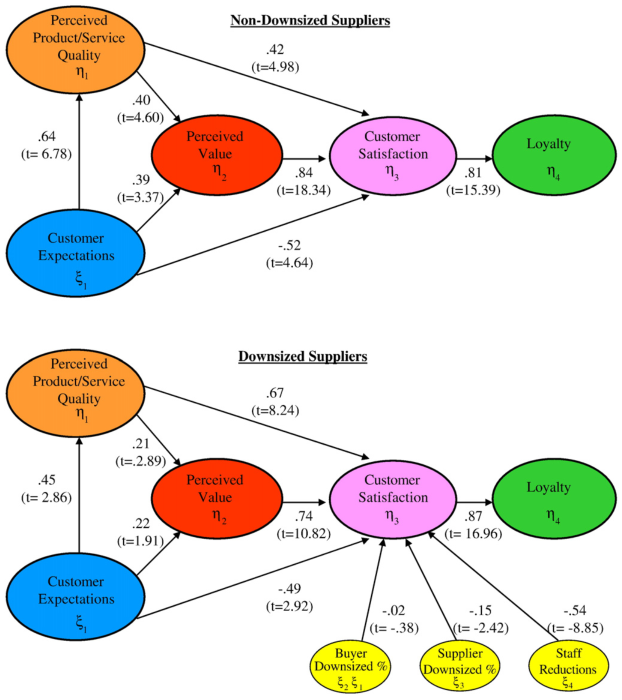

NOTE: figure/graphic rendered as an image from the PDF; its content is not machine-readable text. Caption (if any) follows as the next block.

Fig. 2. Business customer satisfaction.

291 J.E. Lewin / Industrial Marketing Management 38 (2009) 283–299

Page 10

tests of the hypotheses. To accomplish this, a model first is specified with the seven path parameters constrained to be equal across the non-downsized supplier and downsized supplier groups. Then the same model is re-estimated with the parameter equality constraint removed. As in the prior analysis, the unconstrained model exhibits a statistically significant reduction in chi-square value (change in chi-square=48.73, df=7, pb.001), indicating there are at least some differences in parameter strength across the two groups. Next, the individual pairs of parameters between the two groups are evaluated to determine where specific statistical differences exist. This is done by constraining each analogous pair of parameter estimates to be equal across the two groups (one pair at a time), and then evaluating whether the resulting change in chi-square is significant at 1 df. As shown in Table 2, six out of seven paired comparisons are found to be significantly different (pb.001).

For example, the path estimates between pre-purchase expectations and perceived product/service quality are .64 (t= 6.78) for the non-downsized supplier sample, and .45 (t=2.86) for the downsized supplier sample. The difference between these two estimates is statistically significant (pb.001). Thus, the findings indicate that the influence of pre-purchase expectations on post-purchase perceptions of product/service quality is positive in both samples, however the influence is stronger in the non-downsized supplier sample as compared to the downsized sample. The findings indicate similar results for the paths between expectations and value, quality and value, and value and satisfaction. In each case, the results indicate a significant positive relationship among these constructs, with those relationships being stronger in the non-downsized supplier sample as compared to the downsized supplier sample.

In contrast, while the findings indicate that the influence of perceived product/service quality on customer satisfaction is positive in both groups, the influence is stronger in the downsized sample as compared to the non-downsized sample (.42 and .67, respectively). A similar relationship is found for the path between customer satisfaction and loyalty. These latter findings suggest that, in those cases where downsized suppliers (as compared to non-downsized suppliers) are delivering high levels of product/service quality, these quality levels are leading to higher levels of customer satisfaction—which, in turn, result in higher levels of customer loyalty. One possible explanation for these results is that in situations where downsized suppliers ‘get-it right’, they appear to be able to do an excellent job of satisfying their business customers. On the other hand, when downsized suppliers fail to deliver high levels of product/

service quality, the negative impact on business customer satisfaction and loyalty appears to intensify. It is important to note, however, that overall results suggest that the isomorphic forces associated with corporate downsizing often lead to counterproductive outcomes that weaken, rather than strengthen, the downsized firm.

Finally, the only pair of parameters found not to be significantly different is for the path between pre-purchase expectations and customer satisfaction. Interestingly, in each sample the estimated parameter for this path is statistically significant and negative, indicating in both samples that as pre-purchase expectations increase levels of customer satisfaction decrease— and vice versa. This finding is unexpected in light of prior work utilizing the ‘subjective evaluation’ model and indicating a positive relationship between pre-purchase expectations and customer satisfaction (e.g., Fornell et al., 1996; Churchill & Suprenant, 1982). On the other hand, this negative relationship is consistent with Oliver's (1980) ‘subtractive evaluation’ model which suggests that as expectations increase to possibly unachievable levels, satisfaction likely will suffer through negative disconfirmation. One possible explanation for this discrepancy is the difference in the context of this study (business-to-business) as compared to the context of the cited prior work (business-toconsumer). As such, this might be an interesting question for future research investigation. If subsequent investigation supports the negative relationship between expectations and satisfaction found here, one important implication would be that in business buyer–supplier relationships, customer expectations should be managed so as not to inflate buyer expectations beyond the supplier's likely deliverable capabilities.

7. Discussion

The basic propositions underlying this effort are, first, that business customer satisfaction is a critical component of a supplier's current and future performance, as well as an important source of competitive advantage. Second, contrary to recent managerial strategies, significant downsizing of a supplier's sales, service, and/or support personnel can seriously threaten satisfaction levels among that supplier's business customers. The extant literature surrounding customer satisfaction provides strong, consistent support for the importance of customer satisfaction in virtually all manner of ‘competitive’ markets. This supposition is not challenged here. Rather, the question becomes whether or not the downsizing of supplier key contact personnel can influence levels of customer satisfaction in business markets. This remains

Table 2 Comparisons of group parameter estimates

[output not shown]

NOTE: table converted from PDF layout to HTML text; cell boundaries are reconstructed. See PDF if exact alignment matters.

a Constructs: Expectations (EXP), Quality (QUAL), Value (VAL), Satisfaction (SAT), Loyalty (LOY). b Non-downsized Sample (ND), Downsized Sample (DD). c Critical value Δχ2N10.83, pb.001.

292 J.E. Lewin / Industrial Marketing Management 38 (2009) 283–299

Page 11

an important question as downsizing initiatives continue. Since no prior empirical study has undertaken an examination of this important question, this is one of the major contributions of this work. To that end, the argument is made that the downsizing of supplier key contact personnel likely will have a significant negative impact on business customer satisfaction—subsequently leading to reduced levels of customer loyalty. These negative effects on satisfaction and loyalty will result from reductions in downsized suppliers' abilities to provide sufficient levels of quality and value to its customers in competitive environments. The theoretical support for these arguments is drawn from three areas: (1) the services marketing literature (e.g., Estelami & Hurley, 2003; Heskett et al., 1994); (2) the organizational behavior literature (cf. Brockner et al., 1987; Mishra & Spreitzer, 1998); and (3) the strategic management literature (Nixon et al., 2004; Oliva & Sterman, 2001. Based on these prior works, a series of hypotheses are proposed and tested. Study findings indicate first, based on a sample of respondents representing purchasing professionals, that business customers enter into purchasing relationships with relatively high expectations surrounding anticipated levels of supplier product/ service performance. These relatively high levels of pre-purchase performance expectations were generally found across all respondent purchasers. In-and-of-itself, this finding is not surprising given the purchasing professionals' prior experience, industry-specific-knowledge, and the effort they expend in selecting appropriate suppliers. What this finding does in this study, however, is set a baseline for comparison of subsequent performance for non-downsized versus downsized suppliers.

Against this baseline of comparison, and in stark contrast to popular managerial beliefs, downsized suppliers appear to be doing significantly worse, as compared to non-downsized suppliers, in delivering anticipated levels of product/service quality, and thus are perceived by their customers as providing significantly lower levels of overall value. As a result of failing to meet their customers' pre-purchase expectations, coupled with the inability to deliver anticipated levels of quality and value, customers of downsized suppliers are found to be significantly less satisfied. Not surprisingly, as a result, these disappointed customers indicate they intend to purchase less from these downsized suppliers in the near future (1–2 years), and/or plan to replace the current downsized supplier altogether within the next year.

These findings provide the first empirical evidence in a business context of the detrimental effects downsizing might have on the long-term performance of industrial suppliers, via decreases in overall customer satisfaction and loyalty— especially when the ‘jobs cut’ include substantial reductions in sales and service-support personnel. Further, these findings, coupled with recent findings in the finance and management literatures, should provide sufficient motivation for downsizing proponents to reevaluate this popular strategy. This motivation should be further strengthened by beliefs, for example, that a 5% increase in customer loyalty can increase profits from 25% to 85% (Reichheld & Sasser, 1990), and that small changes in customer satisfaction levels can significantly influence a firm's cash flow (Fornell et al., 2006) and equity market value (Fornell et al., 1996).

8. Implications, limitations and future research

8.1. Implications

The results of this research suggest several implications for past, present, and future downsizing organizations, and for firms that are currently competing with downsized organizations. First, while most agree that customer satisfaction should be monitored regularly, the findings reported here indicate the need for satisfaction monitoring is significantly greater for firms that downsize their workforce—especially when that downsizing includes key contact personnel. This would apply equally to firms that have previously downsized, as well as firms that are considering either initial or subsequent downsizing initiatives.

Second, the findings reported here, as well as in other research (DeMeuse et al., 2004; Nixon et al., 2004), suggest that smaller job cuts (as compared to larger cuts), and more strategic cuts that avoid or minimize eliminating key contact personnel (as compared to broad-based/across-the-board cuts) appear to have less impact on business customer satisfaction. Third, in those cases where large broad-based cuts are judged advisable, proactive strategies should be developed to minimize the negative effects on both customer and survivor satisfaction—since the extant literature suggests that satisfaction levels between these two groups are strongly interrelated (Bendapudi & Leone, 2002; Estelami & Hurley, 2003; Heskett et al., 1994; Homburg & Stock, 2004; Oliva & Sterman, 2001; Vilares & Coelho, 2003). Fourth, when firms learn that a competitor either has or is planning to downsize, the downsizing event likely will weaken the competitor firm, providing opportunities to make significant inroads into the downsizing firm's customer base over time.

8.2. Research limitations

The research reported here should be considered exploratory in nature. Some of the constructs have not been examined before in similar contexts to this study. Therefore, the results and implications presented here must be viewed with a certain amount of reservation. Additionally, some of the scales used were either new or were modified for this particular study. While the results of the tests used to assess reliability and validity provide some level of confidence, they must be tested using different samples and multiple methods for further verification. Also, the assumption is made that purchasing professionals, as key informants, are able to provide reliable information on the focal constructs. This assumption is tested using a series of four questions designed to assess respondents' ability to provide meaningful information. While the problems surrounding the use of key informant data has been discussed throughout the literature, key informant data continues to be a widely used methodology.

8.3. Directions for future research

As discussed in this work, decisions to downsize result from a variety of occurrences and pressures, including economic, institutional, and socio-cognitive. Future work in this area might

293 J.E. Lewin / Industrial Marketing Management 38 (2009) 283–299

Page 12

examine if various catalysts to downsizing have (dis)similar outcomes, especially with relation to customer satisfaction and loyalty. A second area of investigation might question what, if any, compensatory adjustments should downsized firms initiate to minimize (or even reverse) the negative impact of downsizing on customer satisfaction.

An interrelated study could examine the relationships and outcomes associated with downsizing and outsourcing. These two practices are frequently linked as often, when cuts are sufficiently ‘deep’, the downsized organization finds itself com-

pelled to outsource some of its requisite functions. Future research might jointly investigate these interrelated practices, and their combined effect on customer satisfaction. Future research also might include an examination of how sales and service-support personnel within downsized organizations perceive their ability to satisfy their business customers. Do they feel better able to satisfy customers as a result of reduced bureaucracy and/or greater empowerment? Or do they feel less able to satisfy customers as a result of excessive workloads and/ or insufficient support?

Appendix A

The questionnaires used for gathering data on downsized and non-downsized suppliers were identical; except for the instructions. For downsized suppliers, respondents were instructed as follows: When answering the following questions we would like you to think of a single current supplier that most closely fits each of the five criteria listed below.

1. A supplier that has either downsized in the past two years and/or is currently downsizing. We define downsizing as ‘a supplier’s intentional, permanent, and systematic reduction in work force size through any number of methods including early retirements, layoffs, merger, etc.' 2. A supplier that you have been purchasing from during the course of their downsizing. In other words, you began purchasing from this supplier before it began downsizing and you are still purchasing from this supplier. 3. A supplier you have either primary or shared purchasing responsibility for at your firm. 4. A supplier whose products and/or services are important, but not critical. 5. A supplier who is not a sole source, in other words alternative suppliers for this product/service are available.

In the case of non-downsized suppliers, respondents were instructed: When answering the following questions we would like you to think of a single current supplier that most closely fits each of the five criteria listed below.

1. A supplier that has not downsized, to the best of your knowledge. 2. A supplier that you have been purchasing from over the course of the past two years, or longer. 3. A supplier you have either primary or shared purchasing responsibility for at your firm. 4. A supplier whose products and/or services are important, but not critical. 5. A supplier who is not a sole source, in other words alternative suppliers for this product/service are available.

Approximately, how long has your firm been buying from this supplier? ______________________ _________________ What is the primary type of product or service you purchase from this supplier? ____________________________________ 1Approximately, to what extent (percent) has this supplier reduced its work force size over the past two years? ___ % Don't know __

1If you don't know, might you provide the name of the firm so that we can determine this? __________________________ In the first two sections of this questionnaire (1. Pre-Purchase Customer Expectations and 2. Post-Purchase Product/Service Quality) we would like to assess how this supplier is currently performing, as compared to your expectations of how this supplier would perform. Therefore, in the first section (1. Pre-Purchase Customer Expectations) please think back to when you first began purchasing from this supplier and recall your initial expectations. If, however, you began purchasing from this supplier a long time ago (i.e., 3+ years), then please think back to your expectations approximately 1–2 years ago. For the rest of the survey, in each section please indicate how well this supplier is currently performing on the items listed.

| 1 PREPURCHASECUSTOMEREXPECTATIONS†⁎ . - | 2 POSTPURCHASEPRODUCT/SERVICEQUALITY . - |
| --- | --- |
| (1=Notveryhighexpectations;10=Veryhighexpectations) | (1=Poor;10=Excellent) |
| Overallproductand/orservicequality | Overallproductand/orservicequality |
| After-sale support | After-sale support |
| Technicalsupport | Technicalsupport |
| Abilitytoreachsupportpersonnel | Abilitytoreachsupportpersonnel |

NOTE: table converted from PDF layout to HTML text; cell boundaries are reconstructed. See PDF if exact alignment matters.

294 J.E. Lewin / Industrial Marketing Management 38 (2009) 283–299

Page 13

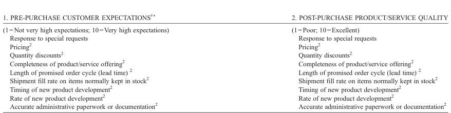

NOTE: complex table shown as an image of the PDF; the text below is a rough machine extraction and may be mis-aligned.

**extracted text (unreliable layout)**

1 These two questions only were included on the downsized supplier questionnaire. 2 Items eliminated from the final analysis during the measure validation process.

[output not shown]

NOTE: table converted from PDF layout to HTML text; cell boundaries are reconstructed. See PDF if exact alignment matters.

7. REDUCTION IN SALES AND SUPPORT PERSONNEL

(1=Strongly Disagree; 10=Strongly Agree)

Staff reductions have not affected this supplier's ability to satisfy my firm<sup>3</sup>

This supplier has experienced a significant turnover of sales reps as a result of downsizing This supplier has experienced a significant turnover of internal customer support personnel as a result of downsizing As a result of this supplier's staff reductions, it has become increasingly difficult to work with this supplier

8. GENERAL INFORMATION

Approximately what were your company's total gross sales in the last full year? ______________________________________ Approximately how many people does your company currently employ? ____________________________________________ Approximately how many years has your company been in business? _______________________________________________ Within what industry or industries does your company primarily operate? ___________________________________________ Has your firm reduced the size of its work force (downsized) in the past two years? __ If so, about how much (%)? _ ____ _ What is your present position or job title? ____________________________________________________________________ How many years have you been working in purchasing? ____ years overall in purchasing —- ____ years with this company Gender? Male □Female □Age? ________ (optional)

3 Reversed coded items.

† In both the Pre-Purchase Expectations and the Post-Purchase Product/Service Quality scales the initial factor analysis resulted in two-factor components. The items loading on the first factor (in both scales) represent the items used in the subsequent analysis. The items loading on the second factor (in both scales) represent the items eliminated from the analysis. The Eigenvalues for the first factors were 6.52 and 7.52, respectively, while the Eigenvalues for the second factors were 1.60 and 1.19, respectively.

⁎ Measurement scales adapted from the following sources:

Customer Expectations: Cronin and Morris (1989) Perceived Product/Service Quality: Cronin and Morris (1989) Perceived Value: Anderson and Narus (1998), Eggert and Ulaga (2002), and Ulaga (2003) Customer Satisfaction: Cannon and Perreault (1999) and Swanson, Kelley, and Dorsch (1998) Loyalty: new scale Staff Reductions: new scale

295 J.E. Lewin / Industrial Marketing Management 38 (2009) 283–299

Page 14

Appendix B. Non-downsizing supplier sample

Parameters for measurement model, item loadings, t-values, composite reliability, and average variance extracted (n=294)

| Items | Customerexpectations | Perceivedquality | Perceivedvalue | Customersatisfaction | Customerloyalty |
| --- | --- | --- | --- | --- | --- |
| E1 | 82(1676) . . | – | – | – | – |
| E2 | 89(1896) . . | – | – | – | – |
| E3 | 83(1703) . . | – | – | – | – |
| E4 | 85(1773) . . | – | – | – | – |
| E5 | 78(1556) . . | – | – | – | – |
| Q1 | – | 84(1756) . . | – | – | – |
| Q2 | – | 88(1892) . . | – | – | – |
| Q3 | – | 83(1729) . . | – | – | – |
| Q4 | – | 88(1889) . . | – | – | – |
| Q5 | – | 85(1791) . . | – | – | – |
| V1 | – | – | 89(1949) . . | – | – |
| V2 | – | – | 87(1849) . . | – | – |
| V3 | – | – | 81(1651) . . | – | – |
| V4 | – | – | 90(1974) . . | – | – |
| V5 | – | – | 91(2013) . . | – | – |
| S1 | – | – | – | 96(2230) . . | – |
| S2 | – | – | – | 94(2132) . . | – |
| S3 | – | – | – | 93(2107) . . | – |
| S4 | – | – | – | 96(2226) . . | – |
| S5 | – | – | – | 85(1812) . . | – |
| L1 | – | – | – | – | 92(2038) . . |
| L2 | – | – | – | – | 77(1547) . . |
| L3 | – | – | – | – | 82(1688) . . |
| L4 | – | – | – | – | 91(2005) . . |
| L5 | – | – | – | – | 82(1688) . . |
| CRa | 92 . | 93 . | 94 . | 97 . | 93 . |
| AVEb | 69 . | 73 . | 77 . | 86 . | 72 . |
| HSVc | 23 . | 42 . | 52 . | 54 . | 48 . |

NOTE: table converted from PDF layout to HTML text; cell boundaries are reconstructed. See PDF if exact alignment matters.

a Composite reliability. b Average variance extracted. a Highest shared variance.

Appendix C. Downsized supplier sample

Parameters for measurement model, item loadings, t-values, composite reliability, and average variance extracted (n=266)

| Items | Customerexpectations | Perceivedquality | Perceivedvalue | Customersatisfaction | Customerloyalty |
| --- | --- | --- | --- | --- | --- |
| E1 | 78(1490) . . | – | – | – | – |
| E2 | 89(1831) . . | – | – | – | – |
| E3 | 85(1695) . . | – | – | – | – |
| E4 | 82(1605) . . | – | – | – | – |
| E5 | 85(1698) . . | – | – | – | – |
| Q1 | – | 81(1581) . . | – | – | – |
| Q2 | – | 93(1996) . . | – | – | – |
| Q3 | – | 91(1917) . . | – | – | – |
| Q4 | – | 85(1718) . . | – | – | – |
| Q5 | – | 86(1739) . . | – | – | – |
| V1 | – | – | 86(1737) . . | – | – |
| V2 | – | – | 85(1699) . . | – | – |
| V3 | – | – | 85(1703) . . | – | – |
| V4 | – | – | 90(1877) . . | – | – |
| V5 | – | – | 94(2018) . . | – | – |
| S1 | – | – | – | 96(2141) . . | – |
| S2 | – | – | – | 98(2222) . . | – |
| S3 | – | – | – | 92(1956) . . | – |
| S4 | – | – | – | 95(2070) . . | – |
| S5 | – | – | – | 85(1733) . . | – |
| L1 | – | – | – | – | 97(2131) . . |
| L2 | – | – | – | – | 82(1611) . . |
| L3 | – | – | – | – | 65(1183) . . |

NOTE: table converted from PDF layout to HTML text; cell boundaries are reconstructed. See PDF if exact alignment matters.

296 J.E. Lewin / Industrial Marketing Management 38 (2009) 283–299

Page 15

(continued)

| Items | Customerexpectations | Perceivedquality | Perceivedvalue | Customersatisfaction | Customerloyalty |
| --- | --- | --- | --- | --- | --- |
| L4 | – | – | – | – | 92(1959) . . |
| L5 | – | – | – | – | 68(1227) . . |
| CRa | 92 . | 95 . | 94 . | 97 . | 91 . |
| AVEb | 71 . | 81 . | 77 . | 87 . | 67 . |
| HSVc | 05 . | 57 . | 61 . | 65 . | 43 . |

NOTE: table converted from PDF layout to HTML text; cell boundaries are reconstructed. See PDF if exact alignment matters.

The results for the control variable measuring supplier sales and customer-support staff reductions are not included above to facilitate ease of comparison across the two samples. However, the results of that analysis are as follows: Item loadings .83, .81, .86, and .97, respectively for each of the four items in this scale. Composite reliability=.93, Average variance extracted=.76, and Highest shared variance=.27.

a Composite reliability. b Average variance extracted. c Highest shared variance.

Appendix D. Means, standard deviations, and Pearson correlations

| Non-downsized supplier sample (n=294) |  |  |  |  |  |  |  |
| --- | --- | --- | --- | --- | --- | --- | --- |
| Construct | Mean | SD | EXP | QUAL | VAL | SAT | LOY |
| Customerexpectations | 839 . | 109 . | 10 . |  |  |  |  |
| Perceivedquality | 832 . | 118 . | 54 . | 10 . |  |  |  |
| Perceivedvalue | 821 . | 130 . | 39 . | 67 . | 10 . |  |  |
| Customersatisfaction | 843 . | 161 . | 26 . | 69 . | 80 . | 10 . |  |
| Customerloyalty | 815 . | 181 . | 20 . | 56 . | 67 . | 76 . | 10 . |

NOTE: table converted from PDF layout to HTML text; cell boundaries are reconstructed. See PDF if exact alignment matters.

All correlations pb.01.

Downsized suppler sample (n=266)

[output not shown]

NOTE: table converted from PDF layout to HTML text; cell boundaries are reconstructed. See PDF if exact alignment matters.

All correlations above .19 pb.01. All correlations above .11 pb.05.

Appendix C (continued )

References

Anderson, E. W., Fornell, C., & Lehmann, D. R. (1994). Customer satisfaction,

market share, and profitability: Findings from Sweden. Journal of Marketing, 58(2), 53−66. Anderson, E. W., Fornell, C., & Rust, R. T. (1997). Customer satisfaction,

productivity, and profitability: Differences between goods and services. Marketing Science, 16(2), 129−145. Anderson, J. C., & Narus, J. A. (1984). A model of the distributor's perspective

of distributor–manufacturer working relationships. Journal of Marketing, 48(4), 62−74. Anderson, J. C., & Narus, J. A. (1990). A model of distributor firm and

manufacturer firm working partnerships. Journal of Marketing, 54(1), 42−58. Anderson, J. C., & Narus, J. A. (1998). Business marketing: Understanding what

customers value. Harvard Business Review, 76(6), 53−65. Bagozzi, R. P., & Yi, Y. (1988). On the evaluation of structural equation models.

Journal of the Academy of Marketing Science, 16(1), 74−94. Bendapudi, N., & Leone, R. P. (2002). Managing business-to-business customer

relationships following key contact employee turnover in a vendor firm. Journal of Marketing, 66(2 l), 83−101. Beverland, M., Napoli, J., & Lindgreen, A. (2007). Industrial global brand

leadership: A capabilities view. Industrial Marketing Management, 36(8), 1082−1093.

Bolton, R. N. (1998). “A dynamic model of the duration of the customer’s

relationship with a continuous service provider: The role of satisfaction. Marketing Science, 17(1), 45−66. Bolton, R. N., Smith, A. K., & Wagner, J. (2003). Striking the right balance.

Journal of Service Research, 5(2), 271−291. Brockner, J. (1988). The effects of work layoffs on survivors: Research, theory,

and practice. Research in Organizational Behavior, 10(1), 213−248. Brockner, J., Grover, S., Reed, T., DeWitt, R. L., & O'Malley, M. (1987). Survivors

reactions to layoffs. Administrative Science Quarterly, 32(2), 526−541. Bryant, B. E. (1997). Bad vibes. Marketing Tools, 4(9), 9−10. Bureau of Labor Statistics Data. (2005). U.S. Department of Labor. www.bls.gov Burton, J. P., Mitchell, T. R., & Lee, T. W. (2005). The role of self-esteem and

social influences in aggressive reactions to interactional injustice. Journal of Business and Psychology, 20, 131−170. Cannon, P. J. & Perreault Jr., W. D. (1999). Buyer–seller relationships in

business markets. Journal of Marketing Research, 36(4), 439−460. Cascio, W. F., Young, C. E., & Morris, J. R. (1997). Financial consequences of

employment-change decisions in major U.S. corporations. Academy of Management Journal, 40(5), 1175−1189. Churchill, G. A., Jr., & Surprenant, C. (1982). An investigation into the

determinants of customer satisfaction. Journal of Marketing Research, 19 (4), 491−504.

297 J.E. Lewin / Industrial Marketing Management 38 (2009) 283–299

Page 16

Cronin, J. J., & Morris, M. H. (1989). Satisfying customer expectations: The

effects on conflict and repurchase intentions in industrial marketing channels. Journal of the Academy of Marketing Science, 17(1), 41−49. CNNMoney. (2005). HP to slash 14,500 jobs. (July 19), www.CNNMoney.com CNNMoney. (2007). Citigroup to hack 17,000 jobs. (April 10), www.

CNNMoney.com De Meuse, K. P., Bergmann, T. J., Vanderheiden, P. A., & Roraff, C. E. (2004). New

evidenceregardingorganizationaldownsizingandafirm'sfinancialperformance: A long-term analysis. Journal of Managerial Issues, 16(3), 155−177. Doney, P. M., & Cannon, J. P. (1997). An examination of the nature of trust in

buyer–seller relationships. Journal of Marketing, 61(2), 35−51. Edwards, R., Gut, A. M., & Mavondo, F. (2007). Buyer animosity in business to

business markets: Evidence from the French nuclear tests. Industrial Marketing Management, 36(4), 483−492. Eggert, A., & Ulaga, W. (2002). Customer perceived value: A substitute for

satisfaction in business markets? Journal of Business & Industrial Marketing, 17(2/3), 107−118. Eisenberg, H. (1997). Reengineering and dumbsizing: Mismanagement of the

knowledge resource. Quality Progress, 30, 57−64. Ennew, C. T., & Ahmed, N. (1999). Managing word of mouth communication.

In A. McAuley & L. Sparks (Eds.), Academy of Marketing, Proceedings of the Annual Conference, 1999. Stirling. Estelami, H., & Hurley, R. F. (2003). Does employee turnover predict customer

satisfaction? Marketing Science Institute Working Paper Series, 4(03-121), 41−56. Ferraro, F., Pfeffer, J., & Sutton, R. I. (2005). Economics language and

assumptions: How theories can become self-fulfilling. Academy of Management Review, 30(1), 8−26. Fornell, C. (1992). A national customer satisfaction barometer: The Swedish

experience. Journal of Marketing, 56(1), 6−21. Fornell, C., Johnson, M. D., Anderson, E. W., Cha, J., & Bryant, B. E. (1996).

The American customer satisfaction index: Nature, purpose, and findings. Journal of Marketing, 60(October), 7−18. Fornell, C., & Larcker, D. F. (1981). Evaluating structural equation models with

unobservable variables and measurement error. Journal of Marketing Research, 18(February), 39−50. Fornell, C., Mithas, S., Morgeson, F. V., III, & Krishnan, M. S. (2006). Customer

satisfaction and stock prices: High returns, low risk. Journal of Marketing, 70(1), 3−14. Ganesan, S. (1994). Determinants of long-term orientation in buyer–seller

relationships. Journal of Marketing, 58(April), 1−19. Granovetter, M. S. (1985). The strength of weak ties. American Journal of

Sociology, 78, 89−95. Gwinner, K. P., Gremler, D. D., & Bitner, M. J. (1998). Relational benefits in

service industries: The customer's perspective. Journal of the Academy of Marketing Science, 26(2), 101−114. Helson, H. (1948). Adaptation-level as a basis for a quantitative theory of frames

of reference. Psychological Review, 55(November), 297−313. Helson, H. (1959). In Sigmund Koch (Ed.), Adaptation level theory, in

psychology: A study of science, Vol. 1. New York: McGraw-Hill. Heskett, J. L., Jones, T. O., Loveman, G. W., Sasser Jr., W. E., & Schlesinger,

L. A. (1994). Putting the service profit chain to work. Harvard Business Review, 72(2l), 164−174. Hodson, R., & Roscigno, V. J. (2004). Organizational success and worker

dignity: Complementary or contradictory. The American Journal of Sociology, 110, 672−708. Homburg, C., & Rudolph, B. (2001). Customer satisfaction in industrial

markets: Dimensional and multiple role issues. Journal of Business Research, 52(1), 15−33. Homburg, C., & Stock, R. M. (2004). The link between salespeople job satisfaction

and customer satisfaction in a business-to-business context: A dyadic analysis. Journal of the Academy of Marketing Science, 32(2), 144−158. Homburg, C., Giering, A., & Menon, A. (2003). relationship characteristics as

moderators of the satisfaction-loyalty link: Findings in a business-tobusiness context. Journal of Business-to-Business Marketing, 10(3), 35−62. Homburg, C., Krohmer, H., Cannon, J. P., & Kiedaisch, I. (2002). Customer

satisfaction in transnational buyer–supplier relationships. Journal of International Marketing, 10(4), 1−29.

Humphreys, M. A., & Williams, M. R. (1996). Exploring the relative effects of

salesperson interpersonal process attributes and technical product attributes on customer satisfaction. Journal of Personal Selling & Sales Management, 16(2), 47−57. Joreskog, K. G., & Sorbom, D. (2001). LISREL 8: User's reference guide.

Scientific Software International, Chicago. Kamakura, W. A., Vikas, M., De Rosa, F., & Mazzon, J. A. (2002). Assessing

the service-profit chain. Marketing Science, 21(3), 294−318. Kumar, P. (2002). The impact of performance, cost, and competitive

considerations on the relationship between satisfaction and repurchase intentions in business markets. Journal of Service Research, 52(3), 55−68. Lam, S. Y., Shankar, V., Erramilli, M. K., & Murthy, B. (2004). Customer

value, satisfaction, loyalty, and switching costs: An illustration from a business-to-business service context. Journal of the Academy of Marketing Science, 32(3), 293−311. Lewin, J. E. (2001). The effects of downsizing on organizational buying

behavior: An empirical examination. Journal of the Academy of Marketing Science, 29(2), 151−166. Lewin, J. E. (2003). An empirical investigation of the effects of downsizing on

buyer–seller relationships. Journal of Business Research, 56(4), 283−293. Lian, P. C. S., & Laing, A. W. (2007). Relationships in the purchasing of

business to business professional services: The role of personal relationships. Industrial Marketing Management, 36, 709−718. Markels, A., & Murray, M. (1996). Slashed and burned: Call it dumbsizing:

Why some companies regret cost-cutting. Wall Street Journal May 14, 1996, A1. McKinley, W., Sanchez, C. M., & Schick, A. G. (1995). Organizational

downsizing: Constraining, cloning, learning. Academy of Management Executive, 9(3), 32−44. McKinley, W., Zhao, J., & Rust, K. (2000). A socio-cognitive interpretation of

organizational downsizing. Academy of Management Review, 25(1), 227−243. Mishra, A., & Spreitzer, G. (1998). Explaining how survivors respond to

downsizing: The roles of trust, empowerment, justice, and work redesign. Academy of Management Review, 23(3), 567−588. Nixon, R. D., Hitt, M. A., Lee, H. U., & Jeong, E. (2004). Market reactions to

announcements of corporate downsizing actions and implementation strategies. Strategic Management Journal, 25(4), 1121−1129. Oliva, R., & Sterman, J. D. (2001). Cutting corners and working overtime: Quality

erosion in the service industry. Management Science, 47(3), 894−914. Oliver, R. L. (1977). Effect of expectation and disconfirmation on post exposure

product evaluations: An alternative interpretations. Journal of Applied Psychology, 62(3), 480−486. Oliver, R. L. (1980). A cognitive model of the antecedents and consequences of

satisfaction decisions. Journal of Marketing Research, 17(4), 460−469. Oliver, R. L. (1999). Whence consumer loyalty? Journal of Marketing,

63(Special Issue), 33−44. Reichheld, F. F., & Sasser Jr., W. E. (1990). Zero defections: Quality comes to

services. Harvard Business Review, 68(5), 105−111. Rokkan, A. I., Heide, J. B., & Wathne, K. H. (2003). Specific investments in

marketing relationships: Expropriation and bonding effects. Journal of Marketing Research, 40(2), 210−224. Rust, R. T., Zeithaml, V., & Lemon, K. (2000). Driving customer equity. Boston:

Free Press. Sharma, A., Grewal, D., & Levy, M. (1995). The customer satisfaction/logistics

interface. Journal of Business Logistics, 16(2), 1−21. Smith, A. K., Bolton, R. N., & Wagner, J. (1999). A model of customer

satisfaction with service encounters involving failure and recovery. Journal of Marketing Research, 36(3), 356−372. Spreng, R. A., MacKenzie, S. B., & Olshavsky, R. W. (1996). A reexamination

of the determinants of consumer satisfaction. Journal of Marketing, 60(3), 15−34. Swanson, S. R., Kelley, S. W., & Dorsch, M. J. (1998). The role of relationship

quality in the stratification of vendors as perceived by customers. Journal of the Academy of Marketing Science, 26(2), 128−142. Tse, D. K., & Wilton, P. C. (1988). Models of consumer satisfaction formation:

An extension. Journal of Marketing Research, 25(2), 204−212. Ulaga, W. (2003). Capturing value creation in business relationships: A

customer perspective. Industrial Marketing Management, 32(8), 677−694.

298 J.E. Lewin / Industrial Marketing Management 38 (2009) 283–299

Page 17

Van Montfort, K., Masurel, E., & Van Rijn, I. (2000). Service satisfaction: An

empirical analysis of consumer satisfaction in financial services. Service Industries Journal, 20(3), 81−94. Vilares, M. J., & Coelho, P. S. (2003). The employee–customer satisfaction

chain in the ECSI model. European Journal of Marketing, 37(11/12), 1703−1722. Wilkinson, A. (2005). Downsizing, rightsizing, or dumbsizing? Quality, human

resources and the management of sustainability. Total Quality Management, 16, 1079−1088. Zeithaml, V. A. (1988). Consumer perceptions of price, quality, and value: A

means-end model and synthesis of evidence. Journal of Marketing, 52(3), 2−22.

Jeffrey Lewin is an Assistant Professor of Marketing at the University of North Texas. His research interests include business buyer–seller relationships and professional selling and sales management. Dr. Lewin's work has been published in a number of scholarly outlets including the Journal of the Academy of Marketing Science, the Journal of Business Research, the Journal of Business & Industrial Marketing, and the Journal of Personal Selling and Sales Management.

299 J.E. Lewin / Industrial Marketing Management 38 (2009) 283–299